# Detroit Schools

Amelia Yurkofsky

5/6/2021

## Introduction

The objective of this analysis is to determine characteristics of Detroit schools that had elevated results during 2016 lead water testing. I’ll use four publicly available data sets: The first three are publicly available data from the City of Detroit’s ‘Detroit’s Open Data Portal’ (two of these - ‘Charter and EEA Schools Water Testing Results’ and ‘DPS Water Testing Results’ - provide information on results of tests for lead in drinking water at 209 Detroit Public Schools that were conducted in 2016, the third, ‘Data from State of Michigan’s Center for Educational Performance and Information,’ provides information on the location and characteristics of these schools, and the final is a publicly available data set with information on neighborhood poverty and income levels. (see Appendix for links to all sources).

```r
suppressPackageStartupMessages(library(readr))
suppressPackageStartupMessages(library(dplyr))

#Import water testing results (downloaded from Detroit Open Data Portal 5/8/2021)
library(readr)
Water_Testing_Results_charter <- read_csv("Charter_and_EEA_Schools_Water_Testing_Results.csv")
Water_Testing_Results_charter$type <- "Charter"
Water_Testing_Results_dps <- read_csv("DPS_Water_Testing_Results.csv")
Water_Testing_Results_dps$type <- "DPS"
water_testing <- rbind(Water_Testing_Results_charter[,c(1,2,7)], Water_Testing_Results_dps[,c(1,2,7)])

#Import school information (downloaded from Detroit Open Data Portal 5/8/2021)
schools_info <- read_csv("Schools__All_Schools__2018_-_2019_.csv")
```

## Preprocessing

In pre-processing I’ll do the following: 1) Dropping unneeded variables, 2) Merging and matching/ fuzzy-matching the data sets by school name, 3) Feature specification, 4) Tackling the class imbalance of the outcome variable.

After dropping redundant and unneeded variables, I’ll focus on the following predictors: Years the school is open, type of school (public or charter), and number of grades. Later I’ll merge in the percent of the population under 100% of the federal poverty ratio by zip code.

```r
#list of variables to keep
vars_keep <- names(schools_info) %in% c("EntityOfficialName", "EntityFIPSCode", "EntityOpenDate", "EntityPhysicalZip4", "type",
                                        "EntityActualGrades", "EntityGeographicLEADistrictOffi","EntityAuthorizedEducationalSett")

#drop unneeded variables
schools_info <- schools_info[vars_keep]
```

The first attempt at merging the school water testing results and school information by school name yielded 87 (out of 209) matches.

```r
#merge
matched <- inner_join(water_testing, schools_info, by = c("school_name"="EntityOfficialName")) #matched
unmatch <- anti_join(water_testing, schools_info, by = c("school_name"="EntityOfficialName"))[,1]
unmatch2 <- anti_join(schools_info, water_testing, by = c("EntityOfficialName"="school_name"))[,1]
unmatch2 <- subset(unmatch2, !is.na(unmatch2$EntityOfficialName))
unmatch2 <- unmatch2 %>% rename(school_name = EntityOfficialName)
dim(matched)[1]
```

```
## [1] 87
```

Because there are a significant number of school names that don’t match, I’ll attempt a process for ‘fuzzy matching’ where I’ll look for the number of words in common between the two lists of school names. Fist I’ll turn each vector of school names into bags-of-words using the qdap package. This results in two lists of list, with each sublist containing the words of the school name without punctuation.

```r
suppressPackageStartupMessages(library(qdap))

#using qdap's "bag_o_words" function to turn each school name into bag of words
unmatch_bag <-sapply(unmatch$school_name, bag_o_words, simplify = TRUE)
unmatch2_bag <- sapply(unmatch2$school_name, bag_o_words, simplify = TRUE)
#look at first 5 school names and their associated bag-of-words
head(unmatch_bag)
```

```
## $`Al-Furqan-Quran Academy`
## [1] "al"      "furqan"  "quran"   "academy"
##
## $`Allen Academy`
## [1] "allen"   "academy"
##
## $`ASA Higher Learning Preparatory School & PreK`
## [1] "asa"         "higher"      "learning"    "preparatory" "school"
## [6] "prek"
##
## $`Cesar Chavez Academy - Martin`
## [1] "cesar"   "chavez"  "academy" "martin"
##
## $`Cesar Chavez Academy - Waterman`
## [1] "cesar"    "chavez"   "academy"  "waterman"
##
## $`Cesar Chavez Academy East Elementary School - Maxwell`
## [1] "cesar"      "chavez"     "academy"    "east"       "elementary"
## [6] "school"     "maxwell"
```

Now I’ll find the length of the intersection each possible pair of bag-of-words. This will provide the number of words that each bag has in common. Then I’ll convert the results to a data frame.

```r
#count the number of shared words between each possible school name pairs
data <- lapply(unmatch_bag, function(x) lapply(unmatch2_bag, function(y) length(intersect(x,y))))

#taking a look at the first five intersections for Cesar Chaves Academy - Waterman
#we can see no words were in common for each of the first five school names
head(data[["Cesar Chavez Academy - Waterman"]])
```

```
## $`Primary Colors Early Childhood Center LLC`
## [1] 0
##
## $`Kiddie University Child Care Center`
## [1] 0
##
## $`Towering Glory Ascension Ministry Church`
## [1] 0
##
## $`Exceptional Deliverance Ministries`
## [1] 0
##
## $`College for Creative Studies`
## [1] 0
##
## $`CAREER CHILD CARE CTR`
## [1] 0
```

```r
#create data frame of results
data2 <- data.frame(do.call(rbind, data))
names(data2) <- unmatch2$school_name
```

```r
#finding schools names with best matches
unmatch$matches <- colnames(data2)[max.col(data2,ties.method="first")]
unmatch$matches2 <- colnames(data2)[max.col(data2,ties.method="last")]
unmatch$matches3 <- colnames(data2)[max.col(data2,ties.method="random")]
unmatch$final_match <- ifelse((unmatch$matches!= unmatch$matches2) &
                              (unmatch$matches2!=unmatch$matches3) &
                                (unmatch$matches3!= unmatch$matches), NA, unmatch$matches)
#keep only the best match
unmatch <- unmatch[,c(1,5)]
unmatch <- subset(unmatch, !is.na(unmatch$final_match))
```

```r
#How many new matches did we get?
dim(unmatch)[1]
```

```
## [1] 97
```

```r
#Spot-checking the matches
sample_n(unmatch, 10)
```

```
## # A tibble: 10 x 2
##    school_name                              final_match
##    <chr>                                    <chr>
##  1 Dossin Elementary Middle School          Dossin Elementary-Middle School
##  2 Beard Early Learning Neighborhood Cente~ Fleming Early Learning Neighborhood~
##  3 Burns Elementary-Middle School & PreK    Burns Elementary-Middle School
##  4 Cesar Chavez Academy - Martin            Cesar Chavez Academy Elementary
##  5 U Prep Academy High School - Red Buildi~ Detroit Edison Public School Academ~
##  6 Robeson/Malcolm X Academy                Paul Robeson Malcolm X Academy
##  7 Cesar Chavez Academy East Elementary Sc~ Cesar Chavez Academy Elementary East
##  8 ASA Higher Learning Preparatory School ~ ASA Higher Learning Preparatory
##  9 U Prep Academy High School - Blue Build~ Detroit Edison Public School Academ~
## 10 Universal Academy & Childcare            Universal Academy
```

```r
#joining with existing matches
matched2 <- inner_join(unmatch, water_testing, by = "school_name") #matched
matched2 <- inner_join(matched2, schools_info, by = c("final_match" = "EntityOfficialName"))
matched2$final_match <- NULL
matched <- rbind(matched, matched2)
```

Now I’ll merge in ‘Income to Poverty Ratios in Michigan by Zip Code Tabulation Area, 2013’ available from Data Driven Detroit (see Appendix for link). The data gives us the percentage of the Michigan population, by zip code, under 100% of the federal poverty ratio.

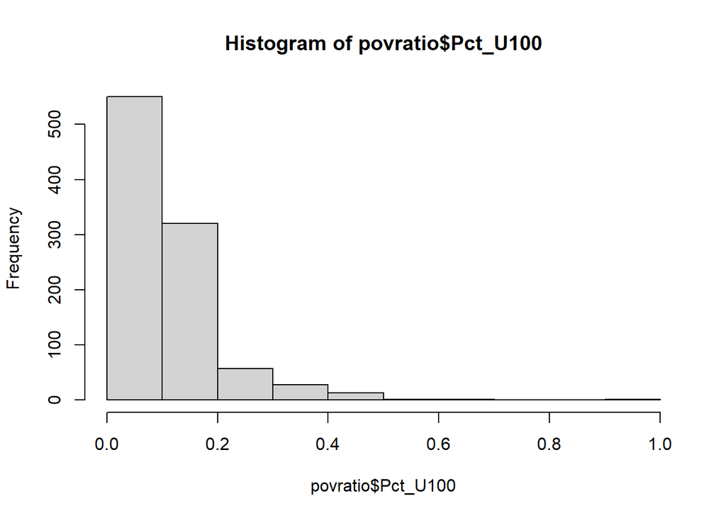

```r
poverty_ratios_2013 <- read_csv("~/911_calls/Income_to_Poverty_Ratios_in_Michigan_by_Zip_Code_Tabulation_Area,_2013.csv")
povratio <- poverty_ratios_2013[,c(3,14)]

hist(povratio$Pct_U100)
```

```r
#cleaning zip codes
matched$zip_code <- substr(matched$EntityPhysicalZip4, 1, 5)
matched$zip_code <- as.numeric(matched$zip_code)
#merge
total <- inner_join(matched, povratio, by = c("zip_code"="ZCTA5CE10"))
```

# Exploratory Data Analysis

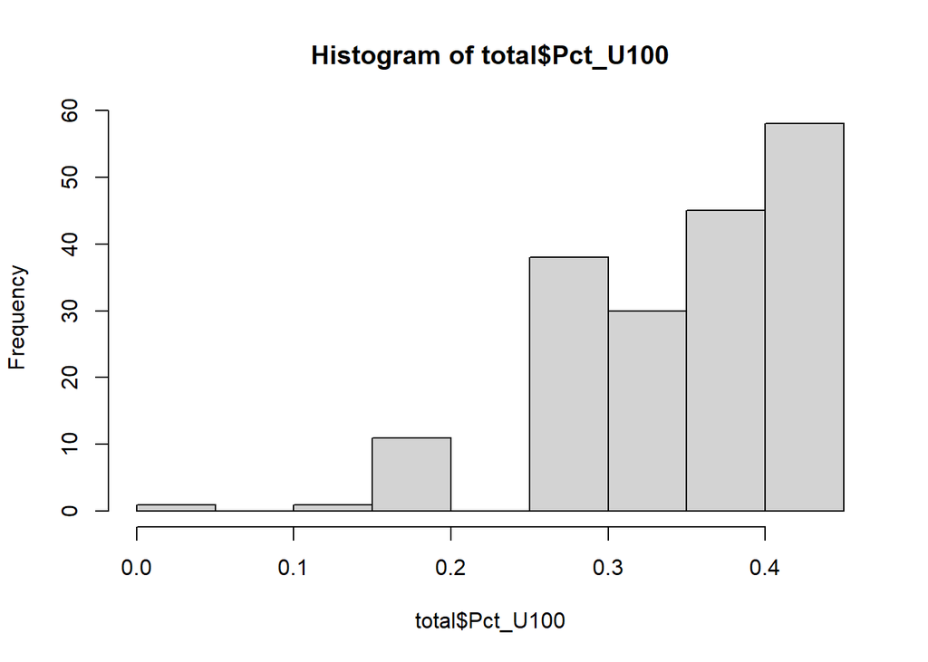

```r
hist(total$Pct_U100)
```

A boxplot of the percentage of the population by zip code below 100% of the federal poverty line shows that the average among schools with elevated lead in their water testing results is slightly higher, 37% vs. 35%, compared to schools with acceptable lead levels. The variance among schools with elevated lead levels is also smaller, with fewer values at low percentage of federal poverty level.

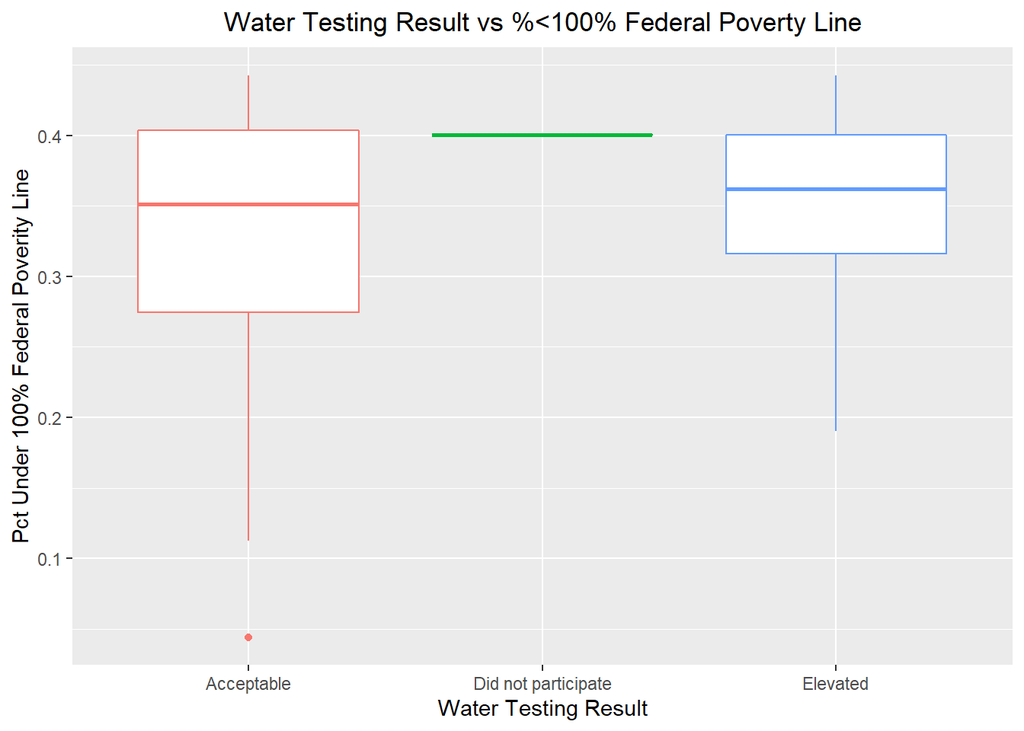

```r
suppressPackageStartupMessages(library(ggplot2))
suppressPackageStartupMessages(library(knitr))

#EDA - Water Testing Results by Federal Poverty Line
ggplot(data = total, aes(x=as.factor(status), y=Pct_U100,
                        color=as.factor(status))) +
  geom_boxplot() +
  xlab('Water Testing Result') +
  ylab('Pct Under 100% Federal Poverity Line') +
  ggtitle('Water Testing Result vs %<100% Federal Poverty Line')  +
  theme(plot.title = element_text(hjust = 0.5), legend.position = "none")
```

We’ll finish exploratory data analysis by cleaning and examining the years the school has been opened and number of grades at the school.

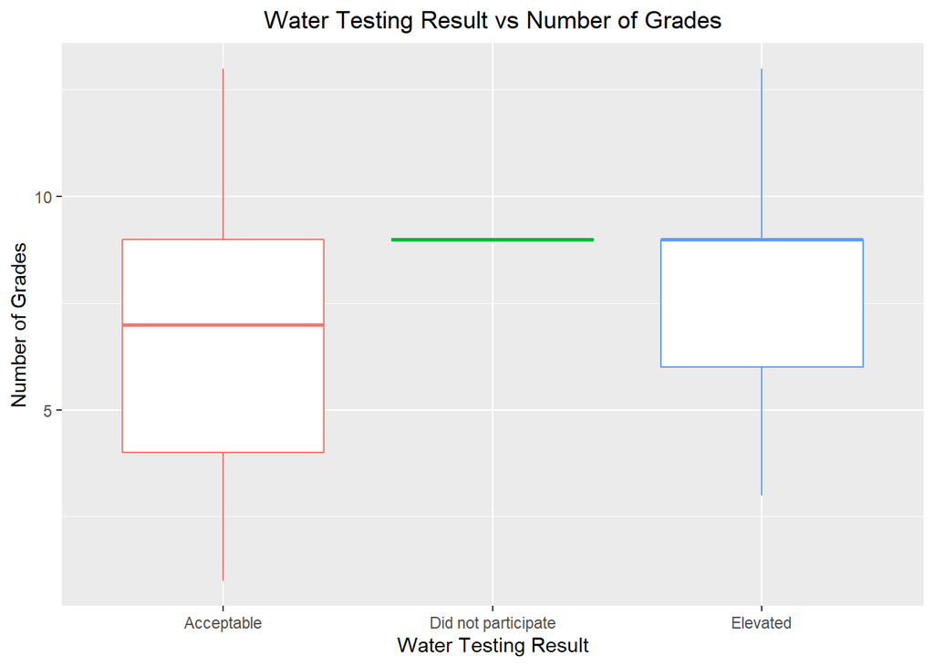

```r
suppressPackageStartupMessages(library(stringr))
suppressPackageStartupMessages(library(lubridate))
suppressPackageStartupMessages(library(knitr))

#number of grades at the schools
total$num_grades <- str_count(total$EntityActualGrades, ',') + 1

#number of years the school has been open
total$years_open <- year(ymd(Sys.Date()))  - year(ymd(as.Date(total$EntityOpenDate)))

#table(total$EntityAuthorizedEducationalSett, useNA = "always")

#EDA - Water Testing Results by Number of Grades
ggplot(data = total, aes(x=as.factor(status), y=num_grades,
                        color=as.factor(status))) +
  geom_boxplot() +
  xlab('Water Testing Result') +
  ylab('Number of Grades') +
  ggtitle('Water Testing Result vs Number of Grades')  +
  theme(plot.title = element_text(hjust = 0.5), legend.position = "none")
```

[figure not shown]

```r
#EDA - Water Testing Results by Years Open
ggplot(data = total, aes(x=as.factor(status), y=years_open,
                        color=as.factor(status))) +
  geom_boxplot() +
  xlab('Water Testing Result') +
  ylab('Years Open') +
  ggtitle('Water Testing Result vs Number of Grades')  +
  theme(plot.title = element_text(hjust = 0.5), legend.position = "none")
```

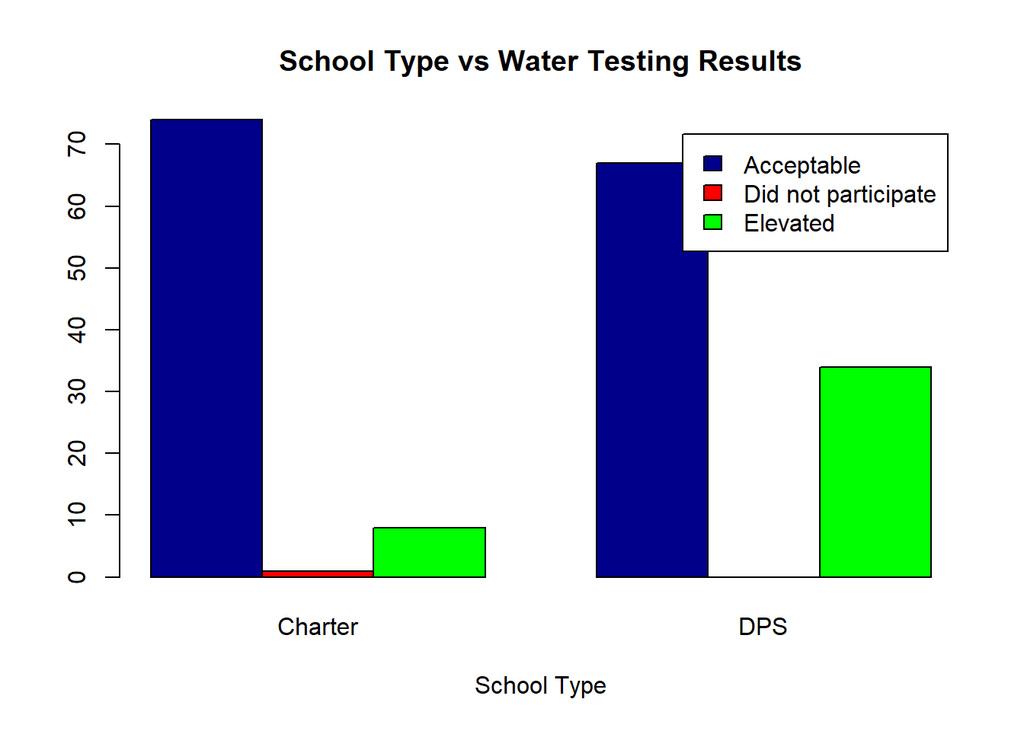

```r
#EDA - Water Testing Results by Years Open
counts <- table(total$status, total$type)
barplot(counts, main="School Type vs Water Testing Results",
  xlab="School Type", col=c("darkblue","red", "green"),
  legend = rownames(counts), beside=TRUE)
```

```r
#cleaning outcome variable
total$elevated <- ifelse(total$status=="Elevated", 1, 0)

#drop unneeded variables
drop_columns <- c('EntityFIPSCode','EntityActualGrades','EntityPhysicalZip4','school_name','EntityOpenDate','status', 'zip_code',
                  'EntityGeographicLEADistrictOff', 'EntityGeographicLEADistrictOffi','EntityAuthorizedEducationalSett')
total <- total[ , !(names(total) %in% drop_columns)]
```

```r
suppressPackageStartupMessages(library(caret))

tabl1 <- table(total$elevated)
kable(tabl1, caption = "Water Testing Results")
```

Water Testing Results

| Var1 | Freq |
| --- | --- |
| 0 | 142 |
| 1 | 42 |

```r
#oversampling majority class
set.seed(1123)
up_sample <- upSample(x = total[, -ncol(total)],y = as.factor(total$elevated))
table(up_sample$elevated)
```

```
## < table of extent 0 >
```

```r
#creating a training and testing set
trainIndex <- createDataPartition(up_sample$Class, p = .7, list = FALSE, times = 1)

totalTrain <- up_sample[ trainIndex,]
totalTest  <- up_sample[-trainIndex,]

#checking class balance
table(totalTrain$Class)
```

```
##
##   0   1
## 100 100
```

```r
table(totalTest$Class)
```

```
##
##  0  1
## 42 42
```

# Methodology

# Results

The classification tree shows that the most important variables are school type (charter or public) and percent poverty level. Detroit Public Schools are more likely than charter schools to have elevated lead schools, and higher percentage of the population under 100% of the federal poverty line are more likely to have elevated lead levels.

```r
library(rpart)
library(rpart.plot)

mod1 <- rpart(Class ~ ., totalTrain)
summary(mod1)
```

```
## Call:
## rpart(formula = Class ~ ., data = totalTrain)
##   n= 200
##
##           CP nsplit rel error xerror       xstd
## 1 0.34000000      0      1.00   1.20 0.06928203
## 2 0.09000000      1      0.66   0.66 0.06649812
## 3 0.02000000      2      0.57   0.58 0.06417164
## 4 0.01333333      4      0.53   0.63 0.06569247
## 5 0.01000000      8      0.46   0.64 0.06596969
##
## Variable importance
##   Pct_U100       type years_open num_grades
##         36         30         30          4
##
## Node number 1: 200 observations,    complexity param=0.34
##   predicted class=0  expected loss=0.5  P(node) =1
##     class counts:   100   100
##    probabilities: 0.500 0.500
##   left son=2 (78 obs) right son=3 (122 obs)
##   Primary splits:
##       type       splits as  LR, improve=12.147960, (0 missing)
##       Pct_U100   < 0.2588713 to the left,  improve= 7.279693, (0 missing)
##       num_grades < 5.5       to the left,  improve= 3.933091, (20 missing)
##       years_open < 73.5      to the left,  improve= 2.925397, (0 missing)
##   Surrogate splits:
##       years_open < 18.5      to the left,  agree=0.775, adj=0.423, (0 split)
##       Pct_U100   < 0.4384079 to the right, agree=0.635, adj=0.064, (0 split)
##
## Node number 2: 78 observations,    complexity param=0.01333333
##   predicted class=0  expected loss=0.2820513  P(node) =0.39
##     class counts:    56    22
##    probabilities: 0.718 0.282
##   left son=4 (13 obs) right son=5 (65 obs)
##   Primary splits:
##       Pct_U100   < 0.2588713 to the left,  improve=2.482051, (0 missing)
##       num_grades < 5.5       to the left,  improve=2.461205, (6 missing)
##       years_open < 21        to the right, improve=1.782847, (0 missing)
##
## Node number 3: 122 observations,    complexity param=0.09
```

[output cut: 93 more lines]

```
##
## Node number 29: 16 observations
##   predicted class=1  expected loss=0.375  P(node) =0.08
##     class counts:     6    10
##    probabilities: 0.375 0.625
##
## Node number 44: 11 observations
##   predicted class=0  expected loss=0.09090909  P(node) =0.055
##     class counts:    10     1
##    probabilities: 0.909 0.091
##
## Node number 45: 17 observations
##   predicted class=1  expected loss=0.4117647  P(node) =0.085
##     class counts:     7    10
##    probabilities: 0.412 0.588
```

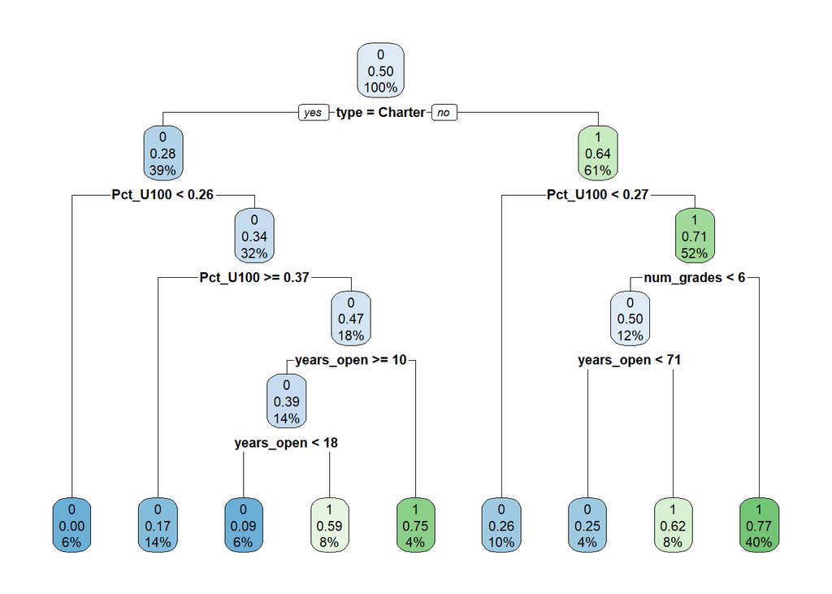

```r
rpart.plot(mod1)
```

# Appendix

- ‘DPS Water Testing Results’: https://data.detroitmi.gov/datasets/dps-water-testing-results
- ‘Charter and EEA Schools Water Testing Results’: https://data.detroitmi.gov/datasets/charter-and-eea-schools-water-testing-results
- ‘Data from State of Michigan’s Center for Educational Performance and Information’: https://data.detroitmi.gov/datasets/2018-2019-schools-eem?geometry=-83.624%2C42.271%2C-82.581%2C42.449
- ‘Income to Poverty Ratios in Michigan by Zip Code Tabulation Area, 2013’: https://portal.datadrivendetroit.org/datasets/a57ee4c6fdd24cd686b2305f2e5bf2a8_0